# Hull White 1F model (Const. Version) calibration in PYTHON

--- Alan Du, 07-21-2020, Shaolun.du@gmail.com

In this notebook, I will calibrate HW1F(const. $a$ and $\sigma$) model from scratch in python based on Libor curve and swaption volatility surface.

As in my previous post, HW1F model has the SDE dynamics as following, for simplicity, we will assume single curve framework (Discounting curve and Forward curve will be the same, in real word, they will be two different curves normally LIBOR for forawrd curve and OIS for discounting and that is called dual curve stripping):

**HullWhite model (Const. Version)** \begin{equation} dr(t) = (\theta(t) - a*r(t)) dt + \sigma dW_t \end{equation}

- $\theta(t)$ is time dependent long term mean rate.
- $a$ is const. mean reversion speed.
- $\sigma$ is const. volatility.
- $r(0) = r_{0}$ the current yield curve instantaneous forward rate.

We directly have some basic information about this SDE:

$$ \begin{aligned} E[r(t)|F_s] &= \frac{E(s)}{E(t)}+a-\frac{E(s)}{E(t)}*a\\ Var[r(t)|F_s] &= V_r(s,t) \end{aligned} $$

To calibrate this model we must solve for $\theta(t) , a , \sigma$.

Here, $\theta(t)$ can be calibrated from initial yield curve. $\sigma$ and $\alpha$ we assume it is const. and not change with time.

We will do the following steps:

- **Prerequisit**: Derive swaption pricing formula under HW1F short rate model dynamic.
- Build initial yield curve for USD LIBOR.
- Get a market panel information of swaptions volatilities and convert them into prices.
- Calculate instantaneous forward rate $f(0,t)$ and all discount factors $P(0,t)$ based on initial yield curve.
- Solve an optimization problem as $$Min(\sum_{i}{(\frac{swo^{market}_{i}-swo^{model}_{i}}{swo^{market}_{i}})^2})$$ with $\sigma$ and $a$ as variables.

Here, $f(0,t)$ means the instantaneous forward rate fixing at time 0 and mature at time t. Mathematically,

$$f(0,t) = -\frac{\partial ln(P(0,t))}{\partial t}$$

From the SDE we can solve for model discount factors: $$ \begin{aligned} P(t,T) &= A(t,T)*e^{-B(t,T)*r_0}\\ r_0 &= inst. fwd\ rate\ at\ 0 \end{aligned} $$ Also, we have defination for $A(t,T), B(t,T)$ and $E(t)$:

$$ \begin{aligned} E(t) &= e^{\int_{0}^{t}a(u)du} = e^{a*t}\\ B(t,T) &= E(t)\int_{t}^{T}\frac{du}{E(u)} = \frac{1}{a}*(1-e^{a*(T-t)})\\ A(t,T) &= ln\frac{P(0,T)}{P(0,t)} + B(t,T)f(0,t)-\frac{1}{2}B(t,T)^2*V_{r}(0,t)\\ V_{r}(s,t) &= \frac{1}{E^2(t)}*\int_{s}^{t}E^2(u)\sigma^2(u)du \end{aligned} $$

```python
# imports libraries
import sys
import math
import datetime
import numpy as np
from scipy import integrate
from scipy.stats import norm
from scipy.optimize import fsolve
from scipy.interpolate import interp1d
from dateutil.relativedelta import relativedelta
from scipy.optimize import fsolve
from scipy.interpolate import CubicSpline
from scipy.interpolate import interp1d
import scipy.optimize as optimize
import matplotlib.pyplot as plt

# All global variables
thismodule = sys.modules[__name__]
# Declear Global variables
_year_days = 365
thismodule._r0 = 0
thismodule._a = 0.1/_year_days
thismodule._sigma = 0.005/_year_days
# Declear States variables
thismodule._A_dict = {}
thismodule._B_dict = {}
thismodule._Vr_dict = {}
thismodule._Vp_dict = {}
```

```python
def _gen_inst_fwd( s, t, _delta ):
    # Numerical differentiation of yield curve
    # to solve for instantaneous forward rate
    # Given discount factor curve
    # return instantaneous forward rate at
    # time t starting from time s
    # assume cv_df is number based not date based axis
    s_df = _cs_dfs(s)
    t_df = _cs_dfs(t)
    t_1_df = _cs_dfs(t+_delta)
    log_pt_T = math.log(t_df/s_df)
    log_pt_T1 = math.log(t_1_df/s_df)
    f_diff = -(log_pt_T1-log_pt_T)/_delta
    return f_diff

def _func_diff(values, t, delta):
    # Cubic splines interpolated curve
    x = [ele[0] for ele in values]
    y = [ele[1] for ele in values]
    _cubic_func = interp1d(x, y,fill_value="extrapolate")
    return (_cubic_func(t+delta)-_cubic_func(t))/delta

# Declear global variable the initial yield curve structure
# Bootstrapped yield curve will be translated into numerical based discount factors curve
_sdate = datetime.date(2020, 7, 16) # Today's date
init_cv = [ [datetime.date(2020, 7, 16), 1], [datetime.date(2020, 9, 16), 0.9995529164730848],
            [datetime.date(2020, 10, 16), 0.9993031259720722], [datetime.date(2020, 12, 16), 0.9987854482642043],
            [datetime.date(2021, 9, 15), 0.9973494133199806], [datetime.date(2021, 12, 15), 0.9968508195808533],
            [datetime.date(2022, 7, 16), 0.995509120724357],  [datetime.date(2023, 7, 16), 0.9930861152838778],
            [datetime.date(2024, 7, 16), 0.9890273445305274], [datetime.date(2025, 1, 16), 0.9866837014553873],
            [datetime.date(2025, 7, 16), 0.9841183184812791], [datetime.date(2026, 1, 16), 0.9808168677885648],
            [datetime.date(2026, 7, 16), 0.9772110778371976], [datetime.date(2027, 1, 16), 0.9733026499097694],
            [datetime.date(2027, 7, 16), 0.9690950050658445], [datetime.date(2028, 1, 16), 0.9650036536742413],
            [datetime.date(2028, 7, 16), 0.9606667498862387], [datetime.date(2029, 1, 16), 0.956107797026265],
            [datetime.date(2029, 7, 16), 0.951307833300792], [datetime.date(2030, 1, 16), 0.946279817911399],
            [datetime.date(2030, 7, 16), 0.9410164524516679], [datetime.date(2031, 1, 16), 0.9362797209716629],
            [datetime.date(2031, 7, 16), 0.9313670172626434], [datetime.date(2032, 1, 16), 0.9262954313572864],
            [datetime.date(2032, 7, 16), 0.921056590382198], [datetime.date(2033, 1, 16), 0.916471169471689],
            [datetime.date(2033, 7, 16), 0.9117619273807694], [datetime.date(2034, 1, 16), 0.906984328074284],
            [datetime.date(2034, 7, 16), 0.9020859000041501], [datetime.date(2035, 1, 16), 0.8971210160137862],
            [datetime.date(2035, 7, 16), 0.8920384117347252], [datetime.date(2036, 1, 16), 0.8876226748095887],
            [datetime.date(2036, 7, 16), 0.8831341079949859], [datetime.date(2037, 1, 16), 0.8786416539058548],
            [datetime.date(2037, 7, 16), 0.8740660685467919], [datetime.date(2038, 1, 16), 0.8694814536205987],
            [datetime.date(2038, 7, 16), 0.8648156588744428], [datetime.date(2039, 1, 16), 0.860141600179927],
            [datetime.date(2039, 7, 16), 0.855388350903013], [datetime.date(2040, 1, 16), 0.8506086202918708],
            [datetime.date(2040, 7, 16), 0.8457631706100335], [datetime.date(2041, 1, 16), 0.8419075708445339],
            [datetime.date(2041, 7, 16), 0.83799979929727], [datetime.date(2042, 1, 16), 0.8341402565876322],
            [datetime.date(2042, 7, 16), 0.8302293342564228], [datetime.date(2043, 1, 16), 0.8263663727178469],
            [datetime.date(2043, 7, 16), 0.8224528249553131], [datetime.date(2044, 1, 16), 0.8185682095886935],
            [datetime.date(2044, 7, 16), 0.8146500215780663], [datetime.date(2045, 1, 16), 0.8107817735709123],
            [datetime.date(2045, 7, 16), 0.8068645315961682], [datetime.date(2046, 1, 16), 0.8033346313504581],
            [datetime.date(2046, 7, 16), 0.7997612196794611], [datetime.date(2047, 1, 16), 0.7962502227759369],
            [datetime.date(2047, 7, 16), 0.7926961973575408], [datetime.date(2048, 1, 16), 0.7891857939776787],
            [datetime.date(2048, 7, 16), 0.7856502648765861], [datetime.date(2049, 1, 16), 0.7821770730975077],
            [datetime.date(2049, 7, 16), 0.7786618129693818], [datetime.date(2050, 1, 16), 0.7752074696360305]]
# Translate date into numerical measure
init_dfs = []
for ele in init_cv:
    init_dfs.append([(ele[0]-_sdate).days,ele[1]])
_init_dfs = init_dfs
x = [ele[0] for ele in _init_dfs]
y = [ele[1] for ele in _init_dfs]
# Cubic splines interpolated yield curve
_cs_dfs = interp1d(x, y,fill_value="extrapolate")
# Time grid units is one day
_delta = 30
_time_grid = list(range(0,_init_dfs[-1][0],_delta))
```

```python
# Annualized spot rate curve
_spot_rate = [[ele,-math.log(_cs_dfs(ele))/(ele)] for ele in _time_grid[1:]]
# Annualized instantaneous fwd rate
_instan_fwd = [[t,_gen_inst_fwd(0,t,_delta)] for t in _time_grid[1:]]
# Differnentiation of instantaneous fwd rate
_diff_instan_fwd = [[t,_func_diff(_instan_fwd,t,_delta)] for t in _time_grid]
_cs_inst_fwd = CubicSpline([ele[0] for ele in _instan_fwd], [ele[1] for ele in _instan_fwd])
_cs_diff_inst_fwd = CubicSpline([ele[0] for ele in _diff_instan_fwd], [ele[1] for ele in _diff_instan_fwd])
# Save r0
thismodule._r0 = _cs_inst_fwd(0)
```

## Step One: $\sigma$ and $a$ should be calibrated into swaption volatility surface

Let's assume we have a receiver swaption with maturity $T_{0}$, tenor $T_{n}$ and strike $K$. So the underlying swap is a receiv fixed payment swap starting from $T_{0}$ and maturied at $T_{n}$, it has two legs which exchange payment at different times normally, the floating leg pays quaterly and the fixed leg pays semiannually. The ATM stike $K_{ATM}$ for this swap can be decided as:

$$ K_{ATM} = \frac{\sum_{i}{Fwd Rate(0,T_{i-1}^{f},T_{i}^{f})*P(0,T_{i}^{f})}}{\sum_{i}{Fixed Rate(0,T_{i-1}^{c},T_{i}^{c})*P(0,T_{i}^{c})}} $$

In this case, the receiver swaption value at time $t$ with strike $K$ can be written as:

$$ swo_{pay}(t,T,K) = E[B(t)^{-1}*(\sum{S_{i}P(t,T_{i}^{f})}-\sum{C_{j}P(t,T_{j}^{c})})] $$

Here, we exclude the final payment of this swap since they will certainly offset each other. The $C_{j}$ terms are fixed rate coupon rates, $S_{i}$ terms are floating rate reset rates. All $P(t,T)$ are discounting factor at time $t$ from time $T$. For example, US swap market standard convention says the fixed rate coupon paying is 6 month and the floating rate paying is 3 month. So $C_{j}$ terms will be 6 month seperate from each other and $S_{i}$ terms will be 3 months seperate from each other.

In order to solve this expectation calculation, we have to use Jamshidian trick and finally arrive the following(I am currently not able to derive SDE calculation that by hand...):

$$ \begin{aligned} swo_{pay}(K,T_{0},T_{p}) &= \sum_{1<=i<=n}{c_{i}ZBP(T_{0},T_{i},X_{i})} \\ c_{i} &= K\delta(T_{i-1},T_{i})\\ c_{n} &= 1+K\delta(T_{n-1},T_{n})\\ X_{i} &= e^{A(T_0,T_i)-B(T_0,T_i)r^*} \end{aligned} $$

where $r^{*}$ is solved from equation below: $$ \sum_{i}{c_{i}*e^{A(T_{0},T_{i})-B(T_{0},T_{i})r^*}} =1 $$

Here, $P(t,T,r)$ means discount factor at time $t$, end at time $T$ with annualized rate $r$. So this equition tells us the fixed coupon receiving cash flow should equal to floating leg paying cash flow under rates $r^*$.

And $ZBP(T_F,T_P,X)$ is zero bond call option price:

$$ \begin{aligned} ZBP(T_F,T_P,X) &= X*P(0,T_F)*\phi(d_{+}) - P(0,T_P)*\phi(d_{-}) \\ d_{+(-)} &= \frac{1}{\sqrt{V_P(0,T_{F},T_{P})}}*log(\frac{P(0,T_F)*X}{P(0,T_P)})+(-)\frac{\sqrt{V_P(0,T_{F},T_{P})}}{2}\\ \end{aligned} $$

where $V_P(0,T_{F},T_{P})$ stands for volatility accumulation given as below:

$$ \begin{aligned} V_P(t,T_{F},T_{P}) &= \int_{t}^{T_F} \sigma^2(B(u,T_P)-B(u,T_F))^2du = V_r(t,T_F)B(T_F,T_P)^2\\ V_{r}(s,t) &= \frac{1}{E^2(t)}*\int_{s}^{t}E^2(u)\sigma^2du \end{aligned} $$

**A quick takeway here shows that the pricing of swaption under hull-white model basically turns into a sun of bunch call options on zero coupon bonds.**

### Tools functions below:

- ZBP pricing: $ZBP_{price}(T_F,T_P,X)$, this function returns pricing of zero bond call option given a.
- Solver for $r^*$: $solver_r(c,s,dfs)$ this funtion solve for the unique $r^*$ satistify $ \sum_{i}{c_{i}e^{A(T_{0},T_{i})-B(T_{0},T_{i})r^*}} =1$

```python
# Plot and check bond price under Hull White model
def _E(t):
    # Calculate E
    ans = math.exp(thismodule._a*t)
    return ans

def _reciprocal_E(u):
    # Calculate reciprocal of E
    ans = _E(u)
    return 1/ans

def _E2_Sigma2(t):
    # Calculate piecewise integration of E
    sig_val = thismodule._sigma
    E = _E(t)
    ans = sig_val*sig_val*E*E
    return ans

def _Vr(s,t):
    # Inputs a and sigma are time dependent lists starting with [0,0]
    res, err = integrate.quad(_E2_Sigma2, s, t)
    e = _E(t)
    return res/(e*e)

def _B(t,T):
    # Calculate integral funtion B
    res, err = integrate.quad(_reciprocal_E, t, T)
    return _E(t)*res

def _A(t,T,Bt_T,Vr0_t):
    # Calculate function A
    sig_val = thismodule._sigma
    a_t = thismodule._a
    P0_T = _cs_dfs(T)
    P0_t = _cs_dfs(t)
    f0_t = _cs_inst_fwd(t)
    a = P0_T/P0_t*math.exp(Bt_T*f0_t-1/2*Bt_T*Bt_T*Vr0_t)
    return a

def _model_P0_Tf(T_x):
    # return model price of Zero coupon bond
    # given information on t=0
    r0 = thismodule._r0
    Vr0_t = thismodule._Vr_dict[(0,T_x)]
    B0_T = thismodule._B_dict[(0,T_x)]
    A0_T = thismodule._A_dict[(0,T_x)]
    bond_price = A0_T*math.exp(-B0_T*r0)
    return bond_price

def _V_P0(T_F,T_P):
    # Simplied version of V_P
    # Calculate accumulated volatility
    B = thismodule._B_dict[(T_F,T_P)]
    Vr = thismodule._Vr_dict[(0,T_F)]
    return B*B*Vr

def _ZBP(T_F,T_P,X):
    # Zero coupon call option pricing under hull-white 1F model
    P0_Tf = _model_P0_Tf(T_F)
    P0_Tp = _model_P0_Tf(T_P)
    V0_Tf_Tp = _V_P0(T_F,T_P)
    d1 = 1/math.sqrt(V0_Tf_Tp)*math.log(P0_Tf*X/P0_Tp) + math.sqrt(V0_Tf_Tp)/2
    d2 = d1-math.sqrt(V0_Tf_Tp)
    price = X*P0_Tf*norm.cdf(d1) - P0_Tp*norm.cdf(d2)
    return price

def _Pswo(K, r_star, pay_dates):
    # Calculate payer swaption price
    sum_f = 0
    T_0 = pay_dates[0]
    Vr_0_t = thismodule._Vr_dict[(0,T_0)]
    for loc in range(1,len(pay_dates)):
        ele = pay_dates[loc]
        c_i = (ele-pay_dates[loc-1])/_year_days*K
        if loc == len(pay_dates)-1:
            c_i += 1
        B = thismodule._B_dict[(T_0,ele)]
        A = thismodule._A_dict[(T_0,ele)]
        X_i = A*math.exp(-B*r_star)
        ZBP_price = _ZBP(T_0,ele,X_i)
        sum_f += c_i*ZBP_price
    return sum_f

def _gen_swap_tb( start, maturity, pay_freq):
    # Swaption table generate
    def diff_month(d1, d2):
        return (d2.year - d1.year) * 12 + d2.month - d1.month
    # Generate swap payment table
    pay_dates = [start+relativedelta(months = pay_freq*i) for i in range(int(diff_month(start, maturity)/pay_freq)+1)]
    pay_dates = [(ele-_sdate).days for ele in pay_dates]
    # Return pay_date are in years unit
    return pay_dates

def _solve_ATM_strike(pay_dates):
    sum_f = 0
    T_0 = pay_dates[0]
    Model_P0 = _model_P0_Tf(T_0)
    sum_dis = 0
    for loc in range(1,len(pay_dates)):
        T_pre = pay_dates[loc-1]
        T_i = pay_dates[loc]
        Model_Pi = _model_P0_Tf(T_i)
        sum_dis += Model_Pi*(T_i-T_pre)/_year_days
        if loc == len(pay_dates)-1:
            Model_Pn = Model_Pi
    K = (Model_P0-Model_Pn)/sum_dis
    return K

def _solve_r(r_star, K, pay_dates):
    # Solver for r*
    T_0 = pay_dates[0]
    sum_f = 0
    Vr_0_t = thismodule._Vr_dict[(0,T_0)]
    for loc in range(1,len(pay_dates)):
        ele = pay_dates[loc]
        c_i = (ele-pay_dates[loc-1])/_year_days*K
        if loc == len(pay_dates)-1:
            c_i += 1
        B = thismodule._B_dict[(T_0,ele)]
        A = thismodule._A_dict[(T_0,ele)]
        sum_f += c_i*A*math.exp(-B*r_star)
    return sum_f-1

# Cached all model states variables given a and sigma
# Will need cached A(t1,t2), B(t1,t2), Vr(t1,t2), Vp(0,t1,t2)
def _update_model_state(swaption_li, pay_freq):
    # Clean all states variables
    thismodule._A_dict = {}
    thismodule._B_dict = {}
    thismodule._Vr_dict = {}
    thismodule._Vp_dict = {}
    for swap in swaption_li:
        swap_start = _sdate+relativedelta(years = swap[0])
        swap_end = swap_start+relativedelta(years = swap[1])
        pay_dates = _gen_swap_tb(swap_start,swap_end,pay_freq)
        T0 = pay_dates[0]
        for pdt in pay_dates:
            # Cached all states variables
            Vr_0_t = _Vr(0,pdt)
            if (0,pdt) not in thismodule._A_dict:
                B = _B(0,pdt)
                A = _A(0,pdt,B,Vr_0_t)
                thismodule._A_dict[(0,pdt)] = A
                thismodule._B_dict[(0,pdt)] = B
                thismodule._Vr_dict[(0,pdt)] = Vr_0_t
            if (T0,pdt) not in thismodule._A_dict:
                B_T0 = _B(T0,pdt)
                A_T0 = _A(T0,pdt,B_T0,Vr_0_t)
                thismodule._A_dict[(T0,pdt)] = A_T0
                thismodule._B_dict[(T0,pdt)] = B_T0
                V0_Tf_Tp = _V_P0(T0,pdt)
                thismodule._Vp_dict[(T0,pdt)] = V0_Tf_Tp
```

### Step Two: Use market swaption quote to calibrate short rate model $a$ and $\sigma$: will be using multivariables optimization in python.

According to our assumption, $a$ and $\sigma$ are constant. In this section we grab some market traded swaption to calibrate our model. That means we will solve for $a$ and $\sigma$ such that the model swaption price can be as close as possible to market swaption price.

As following, market swaptions price with associated attributes (the following table contains calibrated model price comparison with market price which will be detailed later):

[output not shown]

```python
# Define market swaption price diagonal matrix
_market_swaption = [ [5,10,0.0546],
                     [10,5,0.037],
                  ]
```

```python
# Define the solver funtion
def _multi_var_wrap(x0):
    opt_residual = 0
    # Update global variable before optimization
    thismodule._a = x0[0]
    thismodule._sigma = x0[1]
    pay_freq = 6
    _update_model_state(_market_swaption, pay_freq )
    for ele in _market_swaption:
        swap_start = _sdate+relativedelta(years = ele[0])
        swap_end = swap_start+relativedelta(years = ele[1])
        pay_dates = _gen_swap_tb(swap_start,swap_end,6)
        K = _solve_ATM_strike(pay_dates)
        r_star = fsolve(_solve_r, 0, args=(K,pay_dates))
        P_model = _Pswo(K,r_star,pay_dates)
        P_diff = (ele[2]-P_model)/ele[2]
        opt_residual += P_diff*P_diff
    return opt_residual
```

```python
# Define start point
a = 0.1/_year_days
sigma = 0.05/_year_days
x0 = [a,sigma]
bnds = ((0.000001, 1), (0.000001, 1),)
opt_res = optimize.minimize(_multi_var_wrap, x0, method='TNC',bounds=bnds,tol=1e-10)
print(opt_res)
print("Calibration results: a={:.5f}, sigma={:.5f}".format(opt_res.x[0]*_year_days,opt_res.x[1]*_year_days))
```

```
     fun: 0.0009445139398047196
     jac: array([  23.30279408, 1397.53820992])
 message: 'Linear search failed'
    nfev: 159
     nit: 1
  status: 4
 success: False
       x: array([3.03947946e-04, 1.94619375e-06])
Calibration results: a=0.11094, sigma=0.00071
```

```python
# Testing for solved a and sigma model pricnig
thismodule._a = opt_res.x[0]
thismodule._sigma = opt_res.x[1]
for ele in _market_swaption:
    swap_start = _sdate+relativedelta(years = ele[0])
    swap_end = swap_start+relativedelta(years = ele[1])
    pay_dates = _gen_swap_tb(swap_start,swap_end,6)
    K = _solve_ATM_strike(pay_dates)
    r_star = fsolve(_solve_r, 0, args=(K,pay_dates))
    P_model = _Pswo(K,r_star,pay_dates)
    print("Model Swaption Pricing={:.2%}, Actual Pricing={:.2%}, Model Strike={:0.2%}, Diff={:0.2%}".format(P_model,ele[2],K,P_model-ele[2]))
```

```
Model Swaption Pricing=5.36%, Actual Pricing=5.46%, Model Strike=1.16%, Diff=-0.10%
Model Swaption Pricing=3.79%, Actual Pricing=3.70%, Model Strike=1.23%, Diff=0.09%
```

```python
# Testing for swaption pricing co-termin swaption [maturity,tenor,act. price]
_test_swaption = [ [5,10,0.0546], [6,9,0.0531],
                   [7,8,0.0506],
                   [9,6,0.0424], [10,5,0.037],
                  ]
pay_freq = 6
_update_model_state( _test_swaption, pay_freq )
for ele in _test_swaption:
    swap_start = _sdate+relativedelta(years = ele[0])
    swap_end = swap_start+relativedelta(years = ele[1])
    pay_dates = _gen_swap_tb(swap_start,swap_end,6)
    K = _solve_ATM_strike(pay_dates)
    r_star = fsolve(_solve_r, 0, args=(K,pay_dates))
    P_model = _Pswo(K,r_star,pay_dates)
    ele.append(P_model)
    print("Model Swaption({:d},{:d}), Strike={:.2%}, Model Price={:.2%}, Actual Price={:.2%}, Diff={:.2%}".format(ele[0],ele[1],K,P_model,ele[2],P_model-ele[2]))
```

```
Model Swaption(5,10), Strike=1.15%, Model Price=5.33%, Actual Price=5.46%, Diff=-0.13%
Model Swaption(6,9), Strike=1.19%, Model Price=5.23%, Actual Price=5.31%, Diff=-0.08%
Model Swaption(7,8), Strike=1.21%, Model Price=5.01%, Actual Price=5.06%, Diff=-0.05%
Model Swaption(9,6), Strike=1.24%, Model Price=4.27%, Actual Price=4.24%, Diff=0.03%
Model Swaption(10,5), Strike=1.23%, Model Price=3.77%, Actual Price=3.70%, Diff=0.07%
```

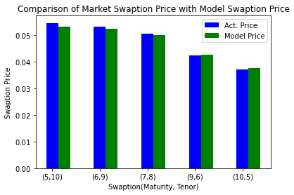

```python
# Model results presentation
X = np.arange(len(_test_swaption))
plt.bar(X + 0.00, [ele[2] for ele in _test_swaption], color = 'b', width = 0.25, label = "Act. Price")
plt.bar(X + 0.25, [ele[3] for ele in _test_swaption], color = 'g', width = 0.25, label = "Model Price")
plt.xticks(X, ('(5,10)', '(6,9)', '(7,8)', '(9,6)', '(10,5)'))
plt.legend()
plt.xlabel('Swaption(Maturity, Tenor)')
plt.ylabel('Swaption Price')
plt.title("Comparison of Market Swaption Price with Model Swaption Price")
plt.show()
```

## Part Two: Theta(t) should be calibrated into initial yield curve term structure

For the function $\theta(t)$ involved in the short rate dynamic and ensuring exact replication of the initial curve with $a$ and $\sigma$ given, we have:

$$ \begin{aligned} \theta(t) &= \frac{\partial{f(0,t)}}{\partial t} + a* f(0,t)+\frac{1}{2}(\frac{\partial^2 V(0,t)}{\partial t^2}+a*\frac{\partial V(0,t)}{\partial t}) \\ &= \frac{\partial{f(0,t)}}{\partial t} + a* f(0,t)+\frac{\sigma^2}{2a}(1-e^{-at}) \\ V(t,T) &= \int_{t}^{T}\sigma^2 du = (T-t)*\sigma^2\\ \sigma(u,T) &= \sigma(u)B(u,T) \end{aligned} $$

Here $f(t,T)$ is the initial instantaneour forward rate fixing at t mature at T.

**In this notebook, we will assume the yield curve is constructed already and we get a list of discount factors with numerical dates as index.**

Details on curve bootstrapping please refer to my previous post on yield curve construction.

```python
def _sigma2_B2(s,t):
    # Calculate piecewise integration of E
    # inputs a is a time dependent list starting with [0,0]
    # assuming integration starts from 0
    sig_val = thismodule._sigma
    B = _B(s,t)
    ans = sig_val*sig_val*B*B
    return ans

def _V(s,t):
    # Calculate V with integration
    res, err = integrate.quad(_sigma2_B2, s, t, args = (t))
    return res

def _P_s_t(s,t):
    # Return zero coupon
    # bond price at time s
    # mature at time t
    s_df = _cs_dfs(s)
    t_df = _cs_dfs(t)
    return t_df/s_df

def _Theta(t):
    # Calculate theta based on initial yield curve
    # Stored all differential vectors beforehand
    f_diff_1 = _cs_inst_fwd(t)
    f_diff_2 = _cs_diff_inst_fwd(t)
    a_t = thismodule._a
    sigma_t = thismodule._sigma
    theta = a_t*f_diff_1+f_diff_2 +1/2*(a_t*_cs_V_diff_1(t)+_cs_V_diff_2(t))
    return theta

def _get_all_theta():
    theta_li = [[t,_Theta(t)] for t in _time_grid]
    return theta_li
```

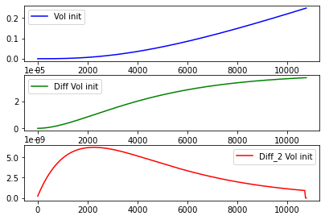

```python
# Accumulated volatility curve
# two volatility curve: the initial volaility curve and short rate volatility curve
_all_V = [[t,_V(0,t)] for t in _time_grid]
# Compute all first derivatives of V values
_all_V_diff_1 = [[i,_func_diff(_all_V, i, _delta )] for i in _time_grid]
_all_V_diff_2 = [[i,_func_diff(_all_V_diff_1, i, _delta )] for i in _time_grid]
# Build cubic Spline of V curve
_cs_V = CubicSpline([ele[0] for ele in _all_V], [ele[1] for ele in _all_V])
_cs_V_diff_1 = CubicSpline([ele[0] for ele in _all_V_diff_1], [ele[1] for ele in _all_V_diff_1])
_cs_V_diff_2 = CubicSpline([ele[0] for ele in _all_V_diff_2], [ele[1] for ele in _all_V_diff_2])
# Subplots
plt.figure()
plt.subplot(311)
plt.plot(_time_grid,[ele[1] for ele in _all_V], color = 'b', label='Vol init')
plt.legend()
plt.subplot(312)
plt.plot(_time_grid,[ele[1] for ele in _all_V_diff_1], color = 'g', label='Diff Vol init')
plt.legend()
plt.subplot(313)
plt.plot(_time_grid,[ele[1] for ele in _all_V_diff_2], color = 'r', label='Diff_2 Vol init')
plt.legend()
plt.subplots_adjust( top=0.92, bottom=0.08,
                     left=0.10, right=0.95,
                     hspace=0.25, wspace=0.35 )
plt.show()
```

Plot of current yield curve discount factors, instantaneous forward rates and first derivatives of instantaneous forward rate.

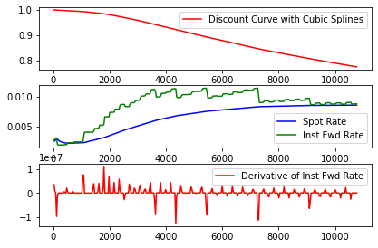

```python
# Annualized spot rate curve
_spot_rate = [[ele,-math.log(_cs_dfs(ele))/(ele)] for ele in _time_grid[1:]]
# Annualized instantaneous fwd rate
_instan_fwd = [[t,_gen_inst_fwd(0,t,_delta)] for t in _time_grid[1:]]
# Differnentiation of instantaneous fwd rate
_diff_instan_fwd = [[t,_func_diff(_instan_fwd,t, _delta)] for t in _time_grid[1:]]

_cs_inst_fwd = CubicSpline([ele[0] for ele in _instan_fwd], [ele[1] for ele in _instan_fwd])
_cs_diff_inst_fwd = CubicSpline([ele[0] for ele in _diff_instan_fwd], [ele[1] for ele in _diff_instan_fwd])

plt.figure()
plt.subplot(311)
plt.plot(_time_grid[1:],[_cs_dfs(ele) for ele in _time_grid[1:]], color = 'r', label='Discount Curve with Cubic Splines')
plt.legend()
plt.subplot(312)
plt.plot([ele[0] for ele in _spot_rate],[ele[1]*_year_days for ele in _spot_rate], color = 'b', label='Spot Rate')
plt.plot([ele[0] for ele in _instan_fwd],[ele[1]*_year_days for ele in _instan_fwd], color = 'g', label='Inst Fwd Rate')
plt.legend()
plt.subplot(313)
plt.plot([ele[0] for ele in _diff_instan_fwd],[ele[1] for ele in _diff_instan_fwd], color = 'r', label='Derivative of Inst Fwd Rate')
plt.legend()
plt.subplots_adjust(top=0.92, bottom=0.08, left=0.10, right=0.95,
                    hspace=0.25,wspace=0.35)
plt.show()
```

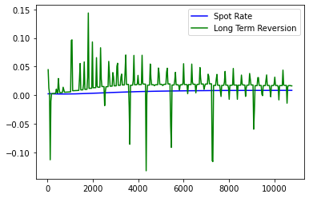

```python
theta_li = _get_all_theta()
plt.figure()
plt.plot([ele[0] for ele in _spot_rate],[ele[1]*_year_days for ele in _spot_rate], color = 'b', label='Spot Rate')
plt.plot([ele[0] for ele in theta_li[1:]],[ele[1]/thismodule._a*_year_days for ele in theta_li[1:]], color = 'g', label='Long Term Reversion')
plt.legend()
plt.show()
```

## Part Three: Simulation future interests rate path based on optimization output

Going back to our original SDE: \begin{equation} dr(t) = (\theta(t) - a*r(t)) dt + \sigma dW_t \end{equation}

We have solved, $\theta$, $a$ and $\sigma$. Next step is to simulate future interests path using Monte Carlo simulation method. Starting point is $r_0$ which is the instantaneous forward rate at current level. Then, we will start generate random normal variables $N(0,1)$ as $dW_t$. Plug into SDE equation to arrive next instantaneous forward rate $r_t$. Eventually, we link all random instantaneous rates together to have a spot interests rate curve and so does the discount factors.

```python
N_path = 1000
delta_t = 30 # Timestep is one month
_time_grid = list(range(0,_init_dfs[-1][0],delta_t))
short_rate_paths = np.zeros((N_path, len(_time_grid)))
spot_rate_paths = np.zeros((N_path, len(_time_grid)))
r0 = thismodule._r0
spot_rate_paths[:,0] = r0
for t_loc in range(1,len(_time_grid)):
    t_time = _time_grid[t_loc]
    theta = _Theta(t_time)
    s_n = np.random.normal(0, 1, N_path).T
    pre_r = short_rate_paths[:,t_loc-1]
    drt = (theta-thismodule._a*pre_r)*delta_t+thismodule._sigma*math.sqrt(delta_t)*s_n
    short_rate_paths[:,t_loc] = pre_r+drt
    spot_rate_paths[:,t_loc] = np.sum(short_rate_paths[:,:t_loc],axis=1)*delta_t/t_time
```

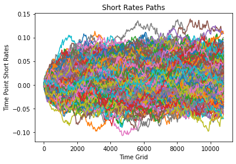

```python
for pp in short_rate_paths:
    plt.plot(_time_grid,pp*_year_days)
plt.xlabel('Time Grid')
plt.ylabel('Time Point Short Rates')
plt.title("Short Rates Paths")
plt.show()
```

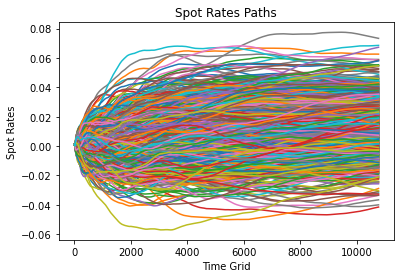

```python
for pp in spot_rate_paths:
    plt.plot(_time_grid,pp*_year_days)
plt.xlabel('Time Grid')
plt.ylabel('Spot Rates')
plt.title("Spot Rates Paths")
plt.show()
```